# Drug sensitivity in cancer cell lines

DAntoni, Marquard, Neumann, Zymela

19 7 2021

# Introduction:

Developing new drugs against certain diseases always is combined with high costs, hard work and complicated requirements before even reaching the market. Therefore an alternative approach of repurposing already approved drugs to new diseases displays an attractive method to save time and resources. On top of that by researching further with these already licensed drugs most safety concerns can be eliminated, since the medications have been thoroughly tested in previous investigations. All in all the potential that drug repurposing possesses helps researchers to create new therapy approaches without the excessive use of follow-up investigations (Pushpakom et al., 2019).

In our research, we worked with multiple datasets that display among other things the growth-inhibitory activity of 4518 different drugs against 481 human cancer cell lines. Here we directed our attention towards pancreatic cancer cell lines, of which there were 33 found in the data provided (Corsello et al., 2020).

The most important datasets we focused on in our research were:  
- the prism Dataset -> containing the treatment effects of the different cell lines  
- the prism.exp Dataset -> containing the gene expression levels for every cell line gene  
- the prism.achilles Dataset -> containing the gene knockdown score for all cell line genes

The following questions we tried to answer over the course of our research:  
- can we identify certain genes that are related to pancreatic cell lines  
- can we determine treatments against these pancreatic cell line genes

# Data Clean-up:

# Descriptive Statistics:

Afterwards we tried to visualize the given datasets to obtain a greater knowledge about their distribution using different dicriptive statistical methods.

## prism dataset

Here we tried to display the data containing the different treatment effects for each cell lines via a heatmap. But since there were to many dimensions to visualise in the prism data set we use on the dimension of treatment only the 100 drugs (perdrug) of the highest variance and on the dimension of cell lines only the pancreatic cancer subset.#

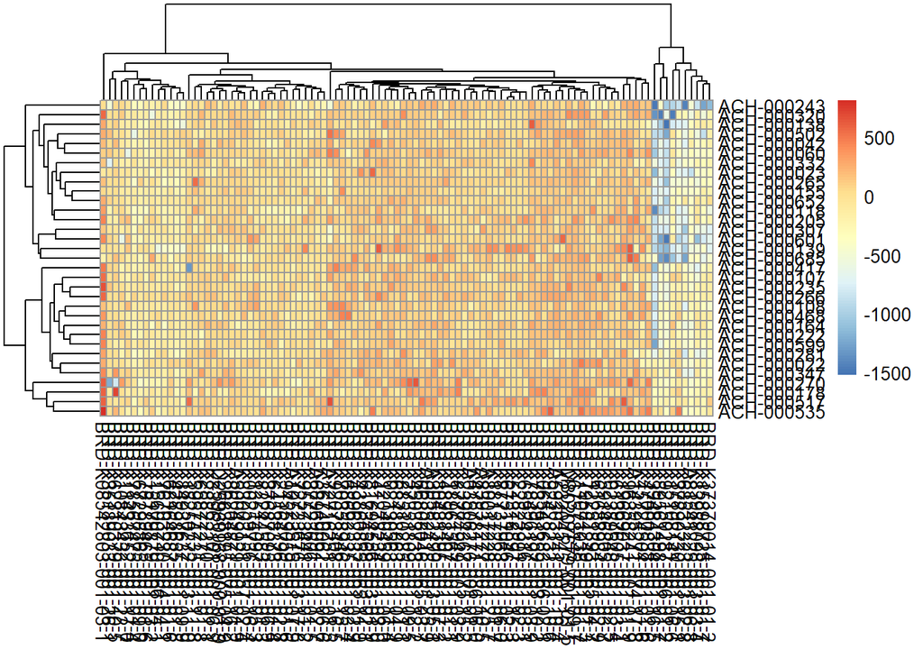

## prism.exp dataset

For this dataset we checked the distribution of the mean gene values of all 481 human cancer cell lines to observe some initial characteristics. This was done using a simple histogram.

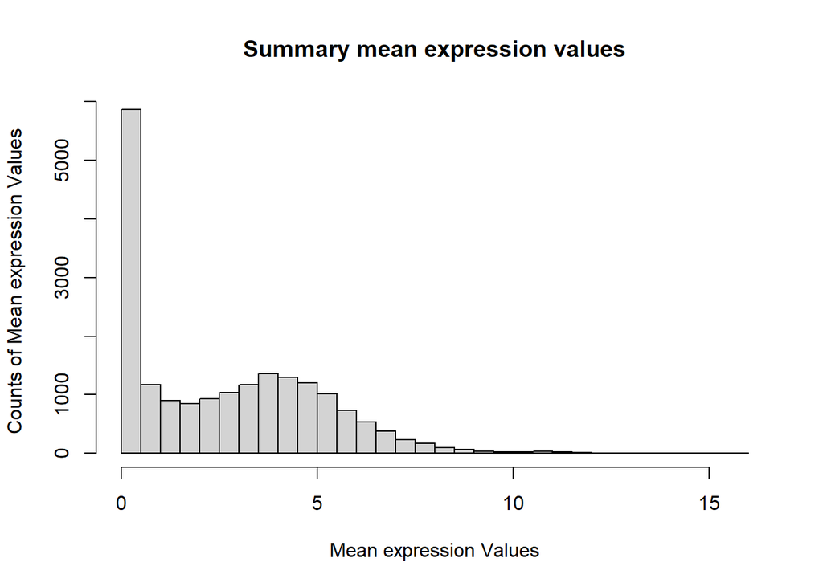

# Using a statistical test to greatly reduce the number of genes of interest

In contrast, identifying interesting genes that are relevant to us turned out to be more difficult. First, it had to be clear what exactly was being searched for. Above all, the aim was to find genes that had distinctive expressions. Such genes whose expression differed significantly from other cancer cell lines. For such a task there are competent methods in statistics, which were also discussed in our bioinformatics lecture. With the help of statistical tests, it is possible to test hypotheses between values of two cohorts and to calculate a p-value, which represents a probability with which a hypothesis can be rejected. For this reason, a corresponding H0 hypothesis was set up for the expression data, paying particular attention to the mean values.

H0: “The mean expression of gene X between pancreatic cancer cell lines and non-pancreatic cancer cell lines is equal”  
H1: “The mean expression of gene X between pancreatic cancer cell lines and non-pancreatic cancer cell lines is different”

One gene from the cohort of 33 pancreatic cancer cell lines and a cohort of 33 randomly selected other cancer cell lines were examined for significant deviations from the mean. Since we were using non-normalized values, we had to use a non-parametric test. Furthermore, we are going to use two-samples, which are unpaired. For that reason, we were using the Wilcoxon Rank Sum Test. In this process, the values of the two groups are combined and given a rank, whereby the information on group membership is not lost. A test statistic is calculated from this, which takes the sum of the ranks in a group into account. The result of the test statistic is compared with critical values, the smaller the result, the more significant the H0 hypothesis can be rejected.

First, in addition to the data frame, which contained cell lines and genes, a data frame with the same number of genes in the same order but with 33 other randomly selected cancer cell lines had to be made. A prism.exp data frame was created for this, which did not contain any pancreatic cancer cell lines. 33 cell lines were randomly selected from this new data frame using the sample function. So, we got two cohorts.

33 values of a gene in one group were compared with 33 values of the same gene in the other pancreatic cancer-free group using the Wilcoxon rank sum test. That alone was not enough to find interesting genes. We had to do the same with all 19177 genes in the data frame. So, a multiple hypothesis test. For this reason, a for loop was used, which took over the procedure column by column. For each gene, the calculated p-value was put into a variable, so that in the end a variable with 19177 values was obtained. Now we can convert the p-values into Boolean values, according to whether these values reach a given significance level alpha or not. It must be noted that the significance level must be adjusted in the case of multiple hypothesis tests, as otherwise the results will be greatly changed by false positive values at high implementation rates. We simply used the Bonferroni correction, whereby the significance value alpha is divided by the number of times, in this case 19177. Any NA values have been replaced by FALSE. This made it possible to produce a vector that contained the names that were significant. The colnames vector of one of the cohorts that had the same sequence of gene names was used for that.

|  | interesting.genes | Freq |
| --- | --- | --- |
| 198 | CLEC11A | 10 |
| 496 | HOXD8 | 9 |
| 512 | ID3 | 8 |
| 513 | ID4 | 8 |
| 848 | OR6M1 | 8 |
| 911 | PLBD1 | 8 |

# Treatment dataset

## Setup and Initiation

All prism data were dose correlated, meaning that a drugs effect on cell growth is normalised to the applied dosage (doscor). Morevover, this doscor data is further processed, where the mean was taken of each drug’s effect per dosage (perdrug). All three—prism, prism.doscor, and prism.perdrug—are then split each into a data set, containing only data for pancreatic cancer cell lines and further into data sets, each containing only cell lines of one of the four subtypes of pancreatic cancer as identified in prism.treat. Then we identified the most efficacious drugs in regards to their ability to inhabit cell growth per applied dosage. To this end we extracted the drugs above the 95th percentile for each of the six data sets: prism.perdrug, pancan.perdrug, and the four perdrug data frames for the four subtypes of pancreatic cancer.

# Preparing Data for Kmeans Clustering

To cluster our cell lines in respect to drug efficacies per dosage, we decided to only use the 100 drugs with the highest variance. To check how many clusters are reasonable we used the elbow method.

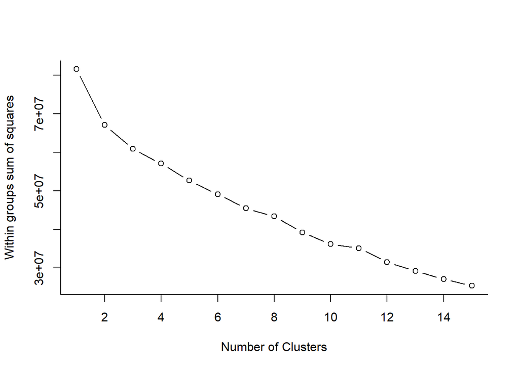

# K-means Clustering

Since the above graph exhibited a kink at i = 2 we chose to use two clusters.

```
##              Length Class  Mode
## cluster       33    -none- numeric
## centers      200    -none- numeric
## totss          1    -none- numeric
## withinss       2    -none- numeric
## tot.withinss   1    -none- numeric
## betweenss      1    -none- numeric
## size           2    -none- numeric
## iter           1    -none- numeric
## ifault         1    -none- numeric
```

To further verify, that our choice of two clusters is the best choice, we check which amount of clusters has the highest average silhouette width. When repeating the clustering with two to 32 clusters we found that the average silhouette width was highest at two clusters, although there are two points that have a negative average silhouette width, indicating an imperfect clustering.

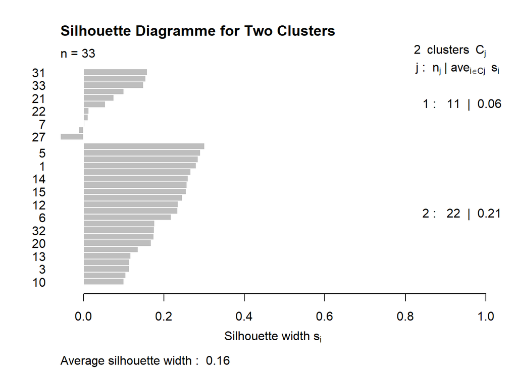

# prism.achilles

## Cleanup of prism.achilles

### NA Removal

The cleanup of prism.achilles consisted of the following steps. Three Rows had to be removed because they contained NAs. These are the corresponding DepMap IDs.

```
## [1] "ACH-000836" "ACH-000901" "ACH-000939"
```

We made Prism.achilles numeric.

For further cleanup we sorted Prism.cl by depmap_id resulting in prism.cl.ordered.

## Exploration of prism.achilles.numeric

New Dataframe for Analysis of prism.achilles.numeric

## The four interesting genes

|  | DOCK5 | KCNK13 | KRAS | WLS |
| --- | --- | --- | --- | --- |
| max | 0.43776386 | 0.53068373 | 0.06927002 | 0.41504652 |
| mean | -0.08222936 | -0.03646742 | -0.58201216 | 0.12194959 |
| min | -1.26474680 | -2.36986289 | -2.15523077 | -0.80051723 |
| 10%quantile | -0.35935966 | -0.14240574 | -1.28502818 | -0.01467511 |
| Pancanmean | -0.41593873 | -0.44466120 | -1.30698799 | -0.02380382 |
| is(r5<r4) | 1.00000000 | 1.00000000 | 1.00000000 | 1.00000000 |
| stdev | 0.05767614 | 0.09384127 | 0.17246569 | 0.01692432 |

Shapiro tests of the four interesting prism.achilles columns shows that their values are not normally distributed. Thus the comparison of the prism.achilles.numeric.pancan mean and prism.achilles.numeric 10% quantile are of no importance until further examination. Shown is the result of a Shapiro-Wilk normality test on column 4283 of our prism.achilles.numeric dataset.

```
##
##  Shapiro-Wilk normality test
##
## data:  prism.achilles.numeric[, 4283]
## W = 0.88736, p-value = 2.696e-15
```

A qqplot between prism.achilles.numeric[,4283] and an according normal distribution results in the following graph. This shows that the values do not correspond to one single normal distribution.

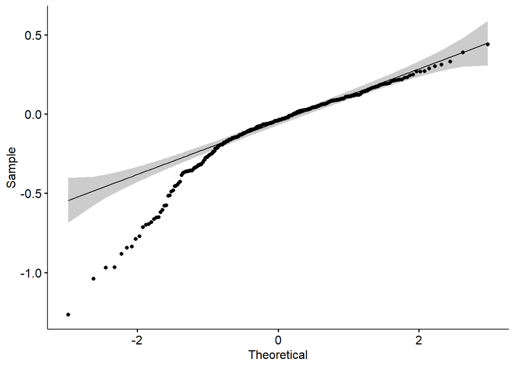

# Regression Analysis

## Preparation for Regression Analysis

We now set up our data upon which our linear regression will be based. We here only use the 5th percentile of the achilles gene data of the highest variance.

## Execution of Regression Analysis

Now we perform the regression analysis for the two best drugs in regard to their ability to inhabit cell growth in pancreatic cancer cell lines.

```
## [1] 0.3412674
## [1] "MIPEP"
## [1] 432
## [1] 0.5502163
## [1] "FBXO11"
## [1] 259
```

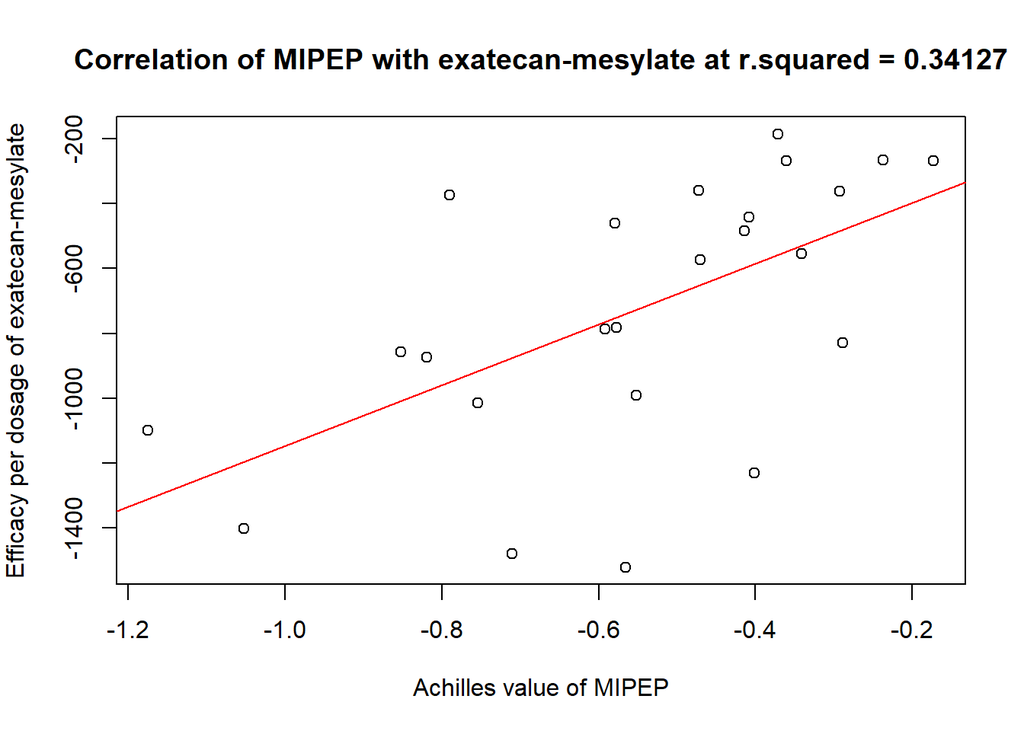

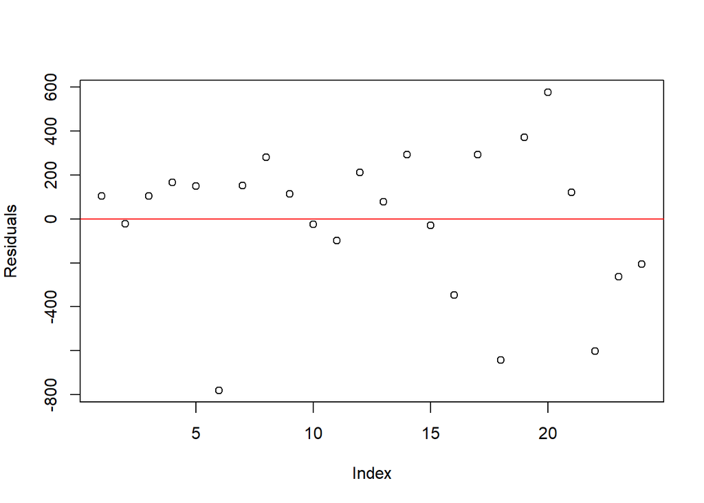

Since the residuals are large and the r²-value is relatively low we can conclude that the achilles value of one gene of a cell is insufficient to explain the efficacy of a drug against said cell.

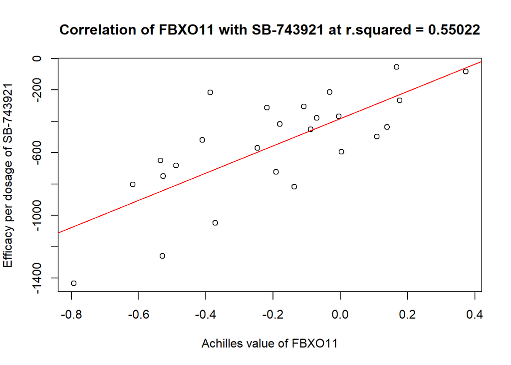

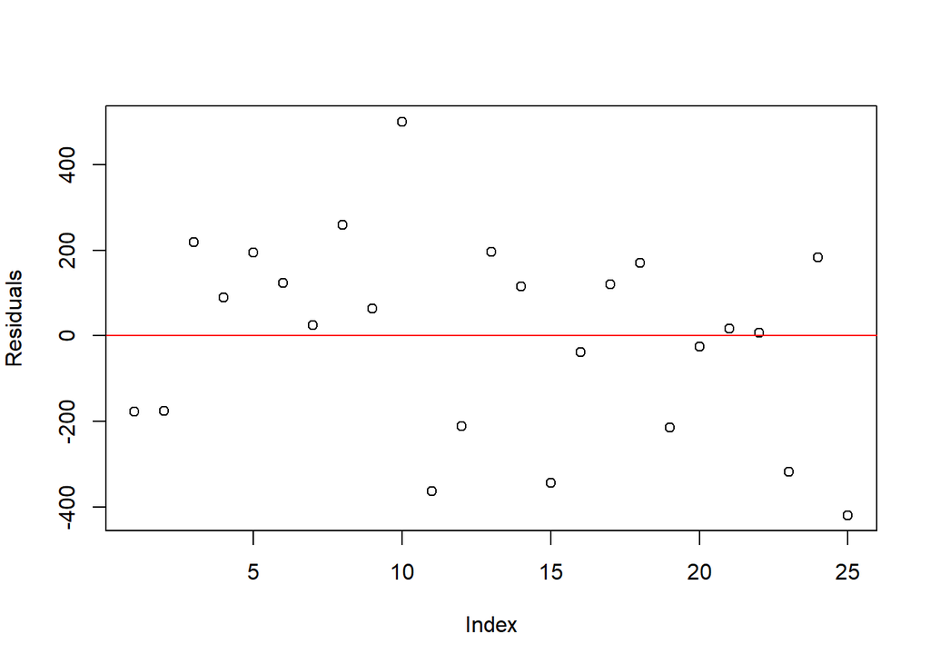

# Discussion

Following up on our two questions mentioned in the beginning, we now identified several different interesting genes that seem to be coupled to pancreatic cell lines. For example we determined the HOXD8 gene, the CLEC11A gene and ID3 gene. All of these genes were shown to possess significantly different mean values when compared to other cancer cell lines. A deeper analysis of the HOXD8 gene showed that this gene seemed to exert a tumor suppressing activity (Mansour & Senga, 2017). Additionally we found four other genes, namely DOCK5, KCNK13, KRAS and WLS. These genes were shown to possess a knockdown score below the 10% quantile of the knockdown score for all other genes. On top of that we also found that exatecan-mesylate had the highest mean efficacy per dosage in inhibiting cell growth of pancreatic cancer cell lines. This is affirmed by research into the antitumor and antimetastatic potential of exatecan-mesylate towards pancreatic cancer cells (Sun et al., 2003). Close contenders were SB-743921 and triptolide.

# Bibliography

Corsello, S.M., Nagari, R.T., Spangler, R.D., Rossen, J., Kocak, M., Bryan, J.G., Humeidi, R., Peck, D., Wu, X., Tang, A.A., et al. (2020). Discovering the anticancer potential of non-oncology drugs by systematic viability profiling. Nature Cancer 1, 235-248. Mansour, M.A., and Senga, T. (2017). HOXD8 exerts a tumor-suppressing role in colorectal cancer as an apoptotic inducer. The International Journal of Biochemistry & Cell Biology 88, 1-13. Pushpakom, S., Iorio, F., Eyers, P.A., Escott, K.J., Hopper, S., Wells, A., Doig, A., Guilliams, T., Latimer, J., McNamee, C., et al. (2019). Drug repurposing: progress, challenges and recommendations. Nature Reviews Drug Discovery 18, 41-58. Sun, F.-X., Tohgo, A., Bouvet, M., Yagi, S., Nassirpour, R., Moossa, A.R., and Hoffman, R.M. (2003). Efficacy of Camptothecin Analog DX-8951f (Exatecan Mesylate) on Human Pancreatic Cancer in an Orthotopic Metastatic Model. Cancer Research 63, 80-85.